# Kelp consumption analysis for urchin deterrence experiment

Amelia Ritger

10/24/2019

### Load packages, load data, tidy data

##### *magic happening behind the scenes*

### Visualize the data

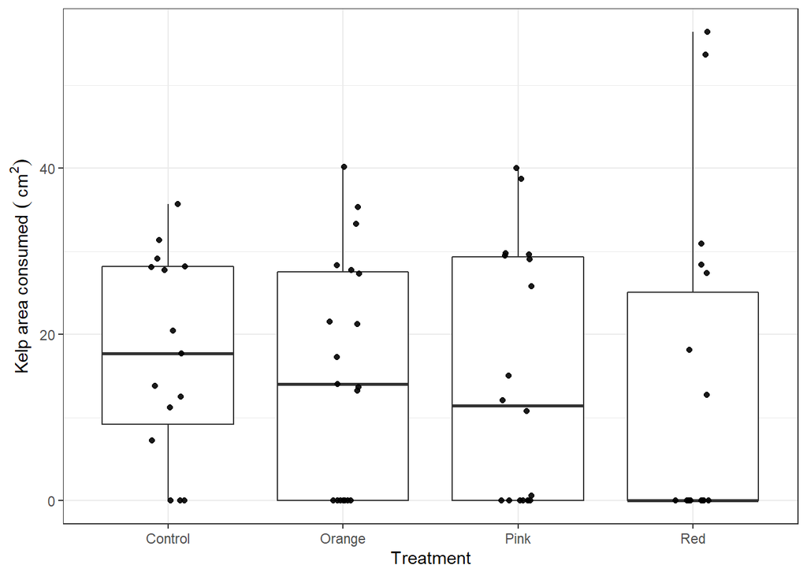

<< This is a potential plot for WSN poster

It looks like there are a lot more zeroes in the experimental treatments versus the control treatment so…

## Is there any difference between urchins that ate or didn’t eat kelp?

#### Rough visualization of distribution using chi-square test

```
##
##  Pearson's Chi-squared test with Yates' continuity correction
##
## data:  cory and eat
## X-squared = 2.2096, df = 1, p-value = 0.1372
```

```
##
##  Pearson's Chi-squared test
##
## data:  t1
## X-squared = 5.9308, df = 3, p-value = 0.115
```

```
## Adjusted p-values used the bonferroni method.
```

```
##           comparison  raw.p  adj.p
## 1 Control vs. Orange 0.4513 1.0000
## 2   Control vs. Pink 0.2828 1.0000
## 3    Control vs. Red 0.0329 0.1974
## 4    Orange vs. Pink 1.0000 1.0000
## 5     Orange vs. Red 0.1939 1.0000
## 6       Pink vs. Red 0.3175 1.0000
```

## What is the effect of Corynactis color on whether or not urchins ate kelp (averaged amongst tiles)?

#### Treat the data as Bernoulli (sucesses vs. failures)

```r
#create the model
library(lme4)
#treating the data as bernoulli, sucesses given failures amongst treatments and tiles
m1 <- glm(cbind(success, count_per_tile-success) ~ treatment, family = binomial , data = data_avg)
summary(m1)
```

```
##
## Call:
## glm(formula = cbind(success, count_per_tile - success) ~ treatment,
##     family = binomial, data = data_avg)
##
## Deviance Residuals:
##     Min       1Q   Median       3Q      Max
## -1.9985  -0.3789  -0.3183   0.9756   1.9437
##
## Coefficients:
##                 Estimate Std. Error z value Pr(>|z|)
## (Intercept)       1.3863     0.6455   2.148   0.0317 *
## treatmentOrange  -0.8473     0.8018  -1.057   0.2906
## treatmentPink    -0.9343     0.8065  -1.158   0.2467
## treatmentRed     -1.8383     0.8065  -2.279   0.0226 *
## ---
## Signif. codes:  0 '***' 0.001 '**' 0.01 '*' 0.05 '.' 0.1 ' ' 1
##
## (Dispersion parameter for binomial family taken to be 1)
##
##     Null deviance: 37.621  on 30  degrees of freedom
## Residual deviance: 31.533  on 27  degrees of freedom
## AIC: 63.099
##
## Number of Fisher Scoring iterations: 3
```

```r
aov(m1)
```

```
## Call:
##    aov(formula = m1)
##
## Terms:
##                 treatment Residuals
## success          118.4968   10.6000
##                   5.60968  11.10000
## Deg. of Freedom         3        27
##
## Residual standard errors: 0.6265721 0.6411795
## Estimated effects may be unbalanced
```

## Among the urchins that ate, does Corynactis matter in how much kelp was consumed?

#### Look at univariate distribution of kelp consumption

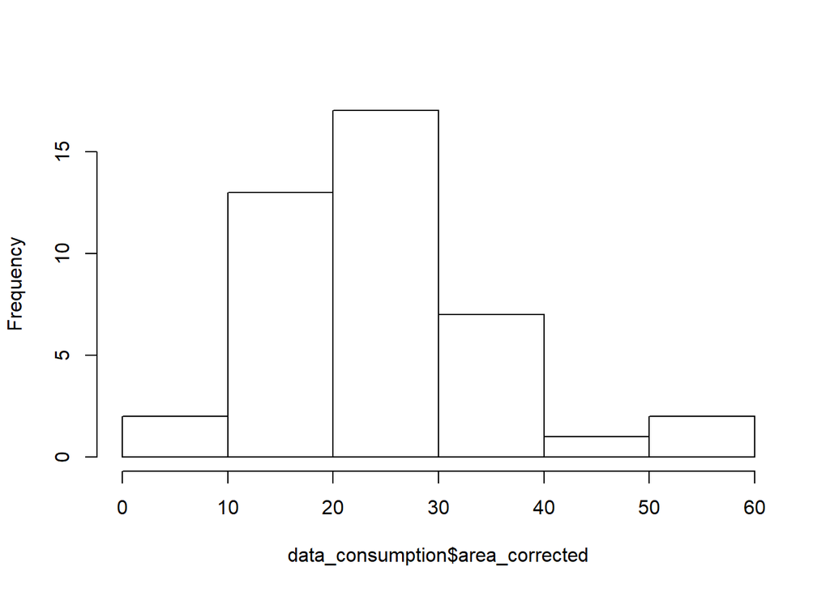

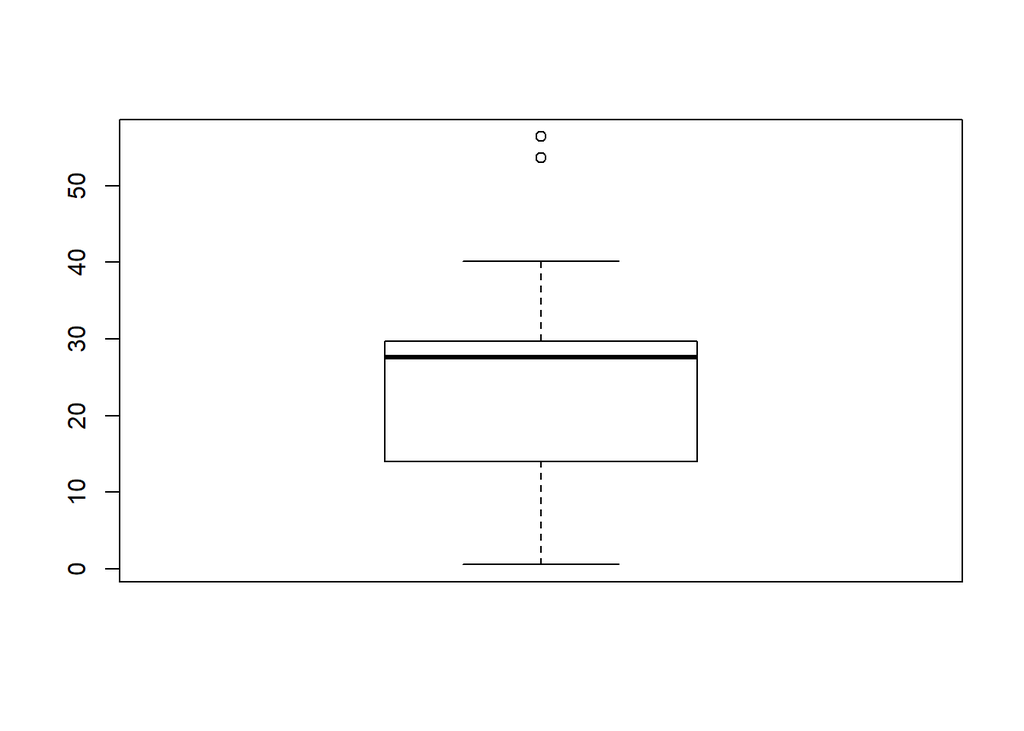

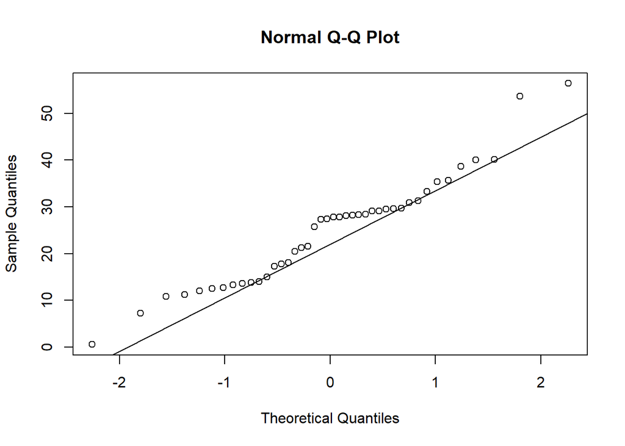

#### Maybe remove two outliers?

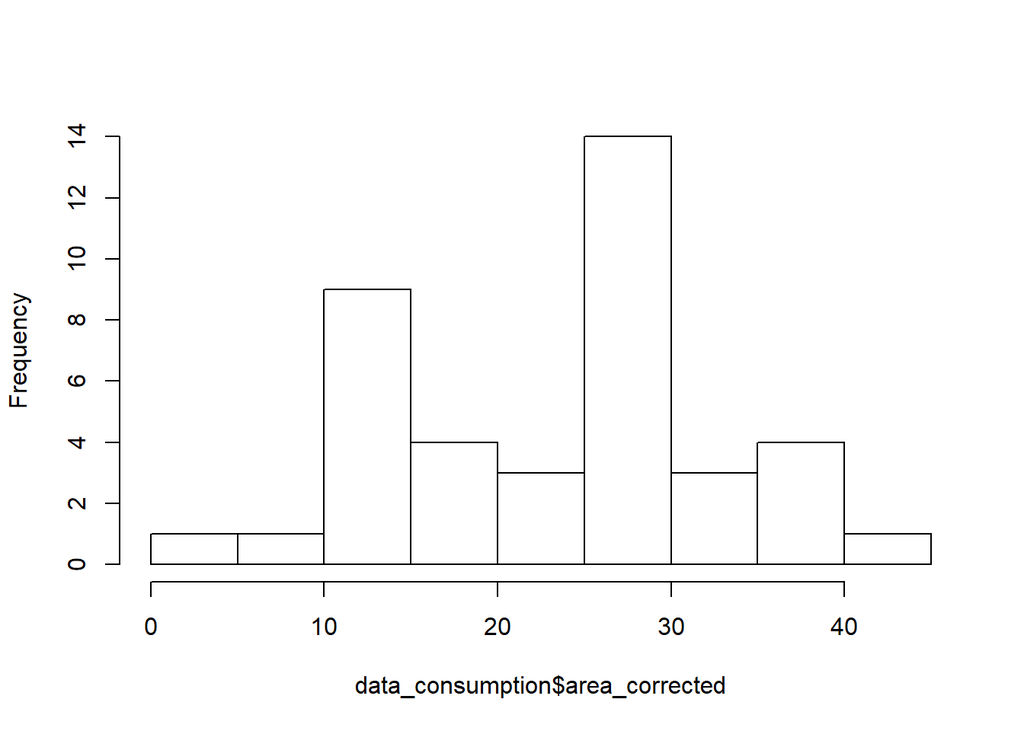

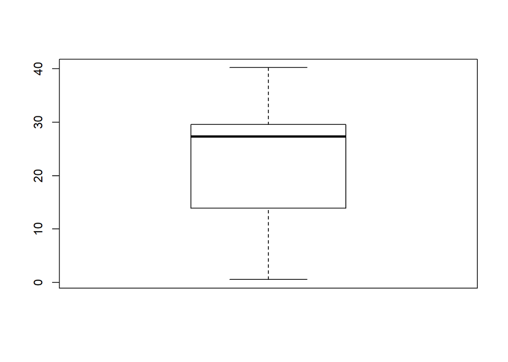

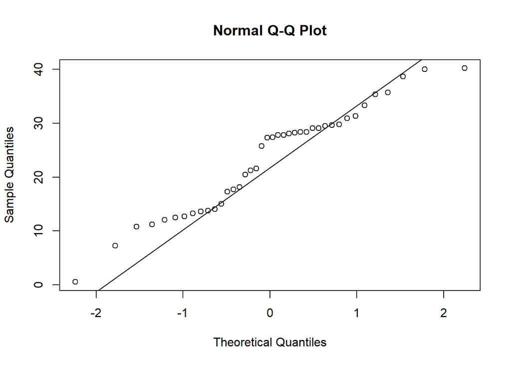

Sure, looks better

#### Now visualize the relationship between treatment and kelp consumption

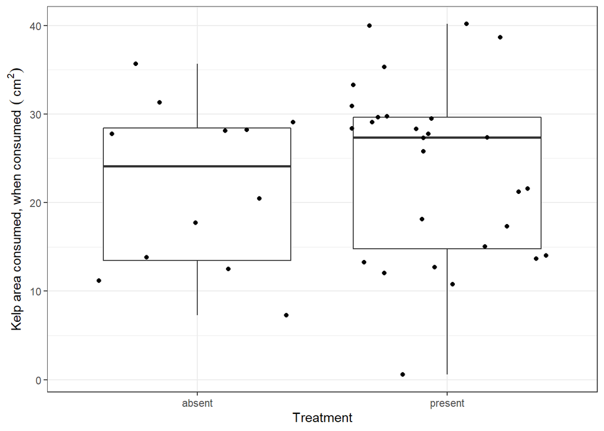

<< This is a potential plot for WSN poster

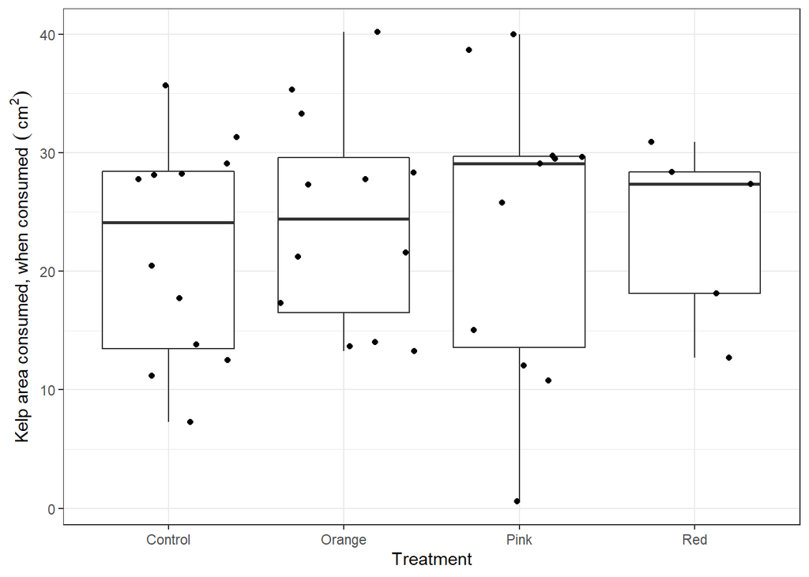

There really is no apparent relationship between presence/absence Corynactis or Treatment and the amount of kelp consumed, but let’s run stats anyway for good measure

### Mixed model ANOVA

#### Treatment is a fixed effect, tile number is a random effect

```
## Linear mixed model fit by REML. t-tests use Satterthwaite's method [
## lmerModLmerTest]
## Formula: area_corrected ~ treatment + (1 | cory_tile_number)
##    Data: data_consumption
##
## REML criterion at convergence: 277.2
##
## Scaled residuals:
##     Min      1Q  Median      3Q     Max
## -2.2553 -0.8677  0.3024  0.6240  1.5906
##
## Random effects:
##  Groups           Name        Variance Std.Dev.
##  cory_tile_number (Intercept)  2.676   1.636
##  Residual                     98.903   9.945
## Number of obs: 40, groups:  cory_tile_number, 23
##
## Fixed effects:
##                 Estimate Std. Error      df t value Pr(>|t|)
## (Intercept)      21.9241     3.3043  0.2185   6.635    0.489
## treatmentOrange   2.5179     4.4151  0.5975   0.570    0.714
## treatmentPink     1.6795     4.4988  0.6508   0.373    0.795
## treatmentRed      1.5188     5.6076  1.3136   0.271    0.823
##
## Correlation of Fixed Effects:
##             (Intr) trtmnO trtmnP
## tretmntOrng -0.748
## treatmntPnk -0.734  0.550
## treatmentRd -0.589  0.441  0.433
```

```
## Type III Analysis of Variance Table with Satterthwaite's method
##           Sum Sq Mean Sq NumDF DenDF F value Pr(>F)
## treatment 32.676  10.892     3     2  0.1101 0.9466
```

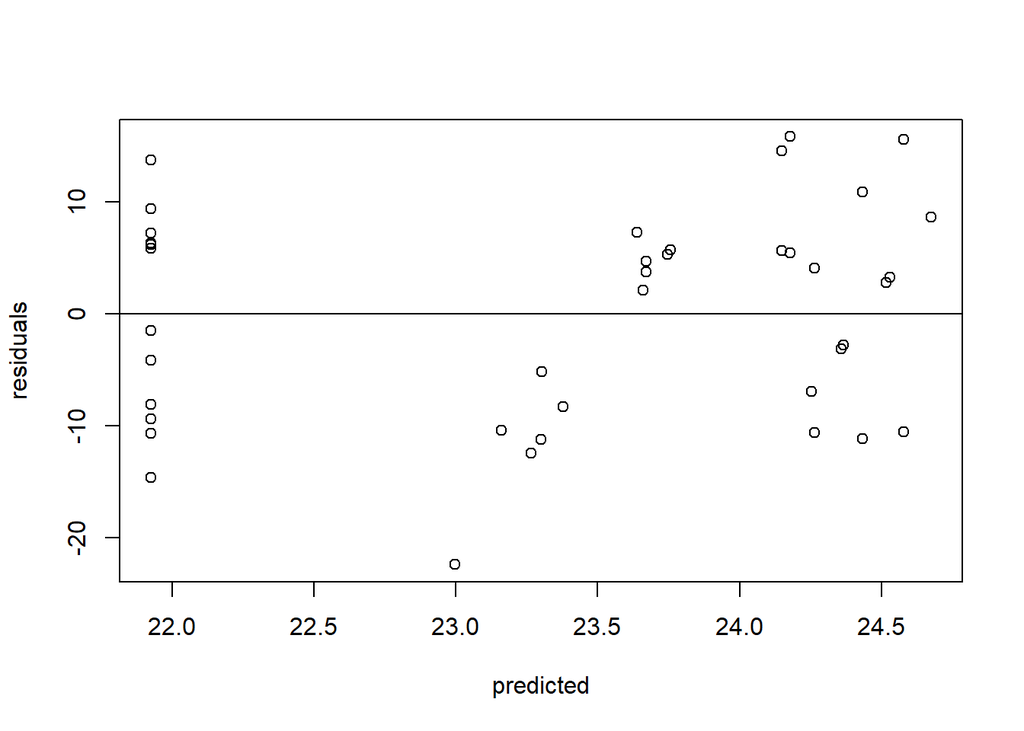

Yep, as suspected, there was no effect of treatment on amount of kelp consumed by urchins, when any kelp was consumed

# So, in conclusion:

#### Red color morph increases probability urchin will fail to eat any kelp

#### But there was no effect of color morph (or even the simple presence of Corynactis) on amount of kelp consumed, when looking only at urchins that did consume kelp

### In the context of WSN, here are a few plots that might be useful for presentations

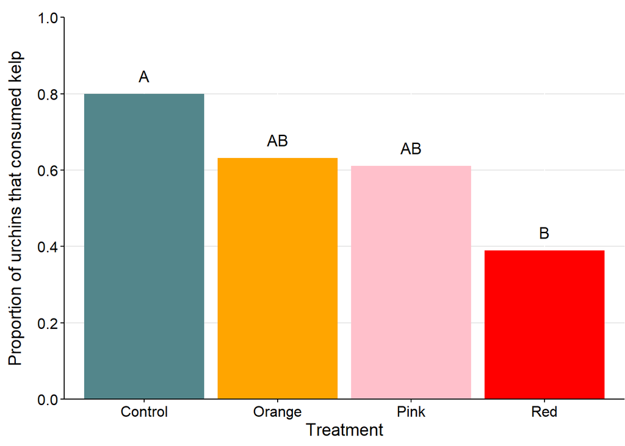

```r
a <- data %>%
  group_by(treatment) %>%
  tally() %>%
  ungroup() #(15,19,18,18)

b <- data %>%
  group_by(treatment) %>%
  summarise(consumption_binary = sum(consumption_binary)) %>%
  ungroup() #(12,12,11,7)

prop <- merge(a,b)

prop <- prop %>%
  mutate(no_eat = n-consumption_binary,
         no_eat_pcnt = no_eat/n,
         eat_pcnt = consumption_binary/n)

ggplot(data=prop, aes(x=treatment, y=eat_pcnt)) +
  geom_col(aes(fill=treatment), show.legend=FALSE) +
  scale_fill_manual(values=c("cadetblue4", "orange", "pink", "red")) + #manually change point colors
  labs(x="Treatment", y="Proportion of urchins that consumed kelp") +
  geom_text(aes(label=c("A", "AB", "AB", "B")), vjust=-1, size=4.5) +
  scale_y_continuous(limits=c(0,1),expand = c(0,0), breaks=c(0,0.2,0.4,0.6,0.8,1)) +
  theme(panel.grid.major.y  = element_line(color = "grey90"),
      panel.background = element_rect(fill = "white"),
      panel.border = element_rect(color = "white", fill = NA),
      axis.line = element_line(color = "black"),
      axis.ticks = element_line(color = "black"),
      axis.text = element_text(color = "black", size=12),
      axis.title.y = element_text(vjust=4, size=14),
      axis.title.x = element_text(size=14),
      plot.margin=unit(c(0.5,0,0.2,0.5), "cm"))
```

```r
ggsave(here::here("figures", "treatment by percent failures.png"), width=6, height=4.5)
```

Let’s see how it looks flipped

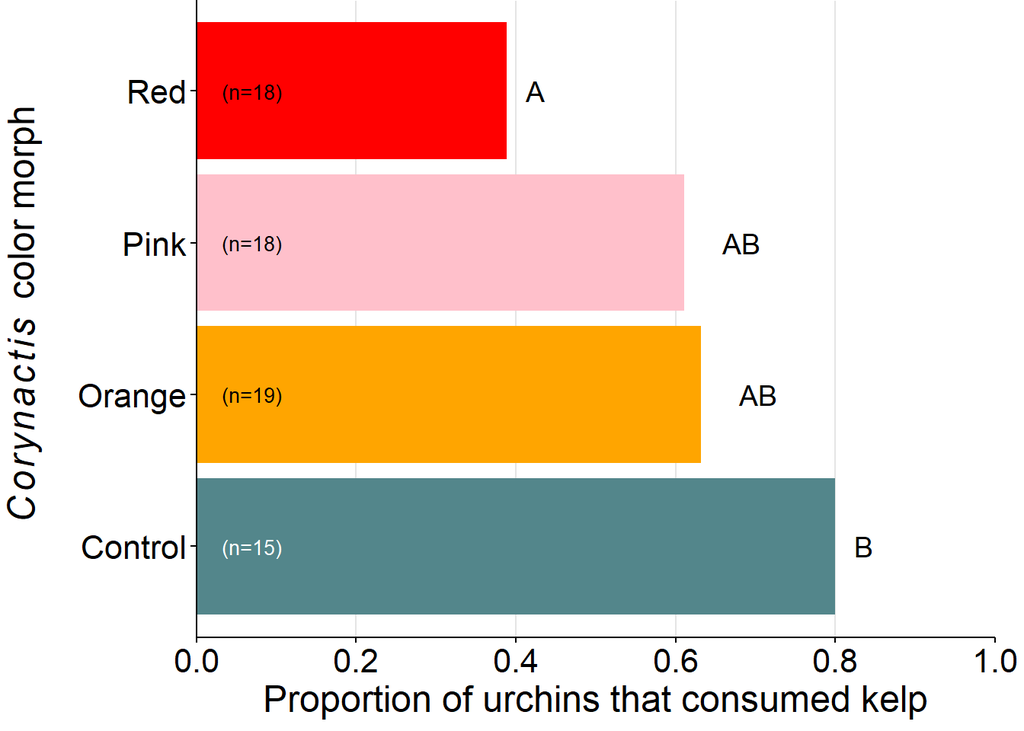

```r
ggplot(data=prop, aes(x=fct_reorder(treatment, -eat_pcnt), y=eat_pcnt)) +
  geom_col(aes(fill=treatment), show.legend=FALSE) +
  scale_fill_manual(values=c("cadetblue4", "orange", "pink", "red")) + #manually change point colors
  labs(x=expression(~italic(Corynactis)~' color morph'), y="Proportion of urchins that consumed kelp") +
  geom_text(aes(label=c("B", "AB", "AB", "A")), hjust=-1, size=5) +
  geom_text(label=c("(n=15)", "(n=19)", "(n=18)", "(n=18)"), color=c("white","black","black","black"), y=0.07, size=3.5) +
  scale_y_continuous(limits=c(0,1),expand = c(0,0), breaks=c(0,0.2,0.4,0.6,0.8,1)) +
  coord_flip() +
  theme(panel.grid.major.x  = element_line(color = "grey90"),
      panel.background = element_rect(fill = "white"),
      panel.border = element_rect(color = "white", fill = NA),
      axis.line = element_line(color = "black"),
      axis.ticks = element_line(color = "black"),
      axis.text = element_text(color = "black", size=16),
      axis.title.y = element_text(vjust=4, size=18),
      axis.title.x = element_text(size=18),
      plot.margin=unit(c(0,0.5,0.2,0.5), "cm"))
```

```r
ggsave(here::here("figures", "treatment by percent failures_h.png"), width=6, height=4.5)
```